# Simulation Studies Based on ACTG175: Binary Endpoint (GLM)

Benefit Subgroup Identification with CD4 Response at 20 Weeks

Author

Larry F. León

Published

April 13, 2026

# 1 Introduction

## 1.1 Motivation

This document extends the ACTG175 benefit-search simulation framework from survival outcomes (time-to-event) to a **binary endpoint**: whether a patient’s CD4 count improved from baseline to 20 weeks, defined as $Y = I(\text{cd420} > \text{cd40})$.

The simulation uses the `forestsearch` GLM simulation suite (`generate_glm_dgm`, `calibrate_glm_interaction`, `simulate_from_glm_dgm`) and routes through `run_simulation_analysis()` via class-based dispatch on the `"glm_dgm"` object.

## 1.2 Statistical Goals

This simulation study addresses three questions about ForestSearch and GRF standalone subgroup identification applied to **binary outcomes**:

1. **Detection power (H1)**: When a benefit subgroup $Q$ exists with OR(Q) = 2 (switched scale), how often do ForestSearch and GRF identify *any* subgroup?
2. **False positive control (H0)**: When the treatment effect is homogeneous (no true $Q$), how often does each method falsely declare a benefit subgroup?
3. **Classification accuracy (H1)**: Conditional on detection, how well does the estimated $\hat{Q}$ recover the true $Q$? Measured by sensitivity ($\text{sens}(\hat{Q})$: fraction of true $Q$ captured) and positive predictive value ($\text{ppv}(\hat{Q})$: fraction of $\hat{Q}$ truly in $Q$).

**TipSummary of results**

See Summary at the end for a data-driven summary of detection, classification, and timing from this run.

## 1.3 Simulation Pipeline

The simulation proceeds in six steps:

1. **Data preparation** (Section 3): Load the ACTG175 trial, restrict to arms 1 (ZDV+ddI) and 3 (ddI), create binary covariates $z_1$–$z_{12}$, and switch treatment labels so ddI = `treat = 1` and ZDV+ddI = `treat = 0` (benefit search convention).
2. **DGM construction** (Section 4): Fit a logistic regression to the observed data, create a 5,000-subject super-population, and define the true benefit subgroup $Q = \{z_1 = 1 \cap z_2 = 1\}$ (age > 34 AND preanti $\leq$ 744.5).
3. **Calibration** (Section 4.2): Search over `k_inter` values to find the interaction strength that produces $\text{OR}(Q) = 2$ on the switched scale (= $0.5$ on the original scale).
4. **Single-data analysis** (Section 5): Run ForestSearch and GRF on the observed ACTG175 data to verify the pipeline produces valid results before scaling to simulation.
5. **Monte Carlo simulation** (Section 7): For each of 5000 alternative and 20000 null replicates, draw a random sample of $N = 1000$ from the DGM super-population, run ForestSearch and GRF, and record detection, classification, and effect estimates.
6. **Evaluation** (Section 8): Compute operating characteristics (detection, sensitivity, PPV, effect estimation bias) under both hypotheses.

## 1.4 Benefit Search on the OR Scale

The benefit-search approach from Leon et al. (2024, Section 4.2) applies identically to binary outcomes, with odds ratios (OR) replacing hazard ratios (HR):

1. **Switch treatment roles**: ddI monotherapy $\to$ `treat = 1`, ZDV+ddI combination $\to$ `treat = 0`.
2. **Raise thresholds** on the OR scale: $c_1 = 1/0.60 \approx 1.667$, $c_2 = 1/0.80 = 1.25$.
3. **Run ForestSearch** with `outcome_type = "binary"`, `effect_measure = "OR"`.
4. **Inversion** is handled automatically by the package when `subgroup_notation = "benefit"` is passed to the reporting functions.

# 2 GRF Standalone: Calibration Summary

The standalone GRF analysis uses `grf.subg.harm.glm()` with `causal_forest()` for candidate factor screening and policy trees for subgroup identification. The key tuning parameter is `dmin.grf`, the minimum absolute CATE (conditional average treatment effect) on the **risk difference** scale required for a policy-tree node to be valid.

## 2.1 Configuration

For the **benefit + positive** scenario with switched treatment (the ACTG175 binary configuration), the correct GRF setup is:

- `adverse_outcome = FALSE` (Y = improvement is positive)
- Treatment indicator = **switched** (ddI = 1, ZDV+ddI = 0)
- GRF identifies the subgroup where the switched “treatment” produces the most negative CATE — i.e., where ddI monotherapy is worst relative to combination, which is the **benefit** subgroup on the original scale

The `adverse_outcome` parameter has **no effect** for this scenario type because the outcome is positive and not flipped.

## 2.2 Calibration Results

The `grf_dmin_calibration_binary.qmd` document evaluated `dmin.grf` across 10 grid points (0 to 0.30) at three effect sizes (weak/moderate/strong), using 1,500 simulations per grid point. Results for the Benefit+Positive scenario:

[output not shown]

# 3 Data Preparation

```r
library(forestsearch)
library(survival)
library(speff2trial)
library(data.table)
library(gt)
library(ggplot2)
library(doFuture)
library(foreach)

# -- Safe foreach result collection -------------------------------------------
# Replaces .errorhandling = "remove" (which silently drops failures)
# with .errorhandling = "pass" + post-hoc separation of errors from results.
collect_results <- function(raw_list, label = "") {
  is_err <- vapply(raw_list, inherits, logical(1), "error")
  n_failed <- sum(is_err)
  if (n_failed > 0) {
    err_msgs <- vapply(raw_list[is_err], conditionMessage, character(1))
    # Use cat() for immediate output (warning/message may be buffered)
    cat(sprintf("*** %s%d of %d tasks failed ***\n",
        if (nzchar(label)) paste0(label, ": ") else "",
        n_failed, length(raw_list)))
    cat("  First errors:\n")
    for (msg in head(unique(err_msgs), 3)) cat("    ", msg, "\n")
  }
  good <- raw_list[!is_err]
  if (length(good) == 0) {
    # Return empty data.frame instead of NULL to avoid attr() crash
    result <- data.frame()
    warning(sprintf("%sAll %d tasks failed. See error messages above.",
        if (nzchar(label)) paste0(label, ": ") else "",
        length(raw_list)))
  } else if (requireNamespace("data.table", quietly = TRUE)) {
    result <- data.table::rbindlist(good, use.names = TRUE, fill = TRUE)
    result <- as.data.frame(result)
  } else {
    result <- do.call(rbind, good)
  }
  attr(result, "n_failed") <- n_failed
  attr(result, "n_total") <- length(raw_list)
  result
}
```

```r
t0 <- proc.time()[3]

# -- ACTG175: arms 1 (ZDV+ddI) vs 3 (ddI) ------------------------------------
actg_df <- subset(speff2trial::ACTG175, arms %in% actg_arms)
actg_df$id <- seq_len(nrow(actg_df))

# Original treatment: arm 1 = 1, arm 3 = 0
actg_df$treat_orig <- ifelse(actg_df$arms == actg_treat_arm, 1L, 0L)

# Switched treatment for benefit search
actg_df$treat <- 1L - actg_df$treat_orig

# -- Binary outcome: CD4 response at 20 weeks ---------------------------------
actg_df$y_binary <- as.integer(actg_df$cd420 > actg_df$cd40)

# Remove subjects with missing cd420
n_before <- nrow(actg_df)
actg_df <- actg_df[!is.na(actg_df$cd420), ]
n_after  <- nrow(actg_df)

cat(sprintf("ACTG175: N = %d -> %d after removing %d with missing cd420\n",
    n_before, n_after, n_before - n_after))
```

```
#> ACTG175: N = 1083 -> 1083 after removing 0 with missing cd420
```

```r
cat(sprintf("Overall response rate: %.1f%%\n",
    100 * mean(actg_df$y_binary)))
```

```
#> Overall response rate: 60.3%
```

```r
cat(sprintf("  ZDV+ddI (arm 1): %.1f%%\n",
    100 * mean(actg_df$y_binary[actg_df$treat_orig == 1])))
```

```
#>   ZDV+ddI (arm 1): 65.3%
```

```r
cat(sprintf("  ddI (arm 3):     %.1f%%\n",
    100 * mean(actg_df$y_binary[actg_df$treat_orig == 0])))
```

```
#>   ddI (arm 3):     55.6%
```

```r
# -- Discretise covariates (same as survival version) --------------------------
actg_df$z1  <- as.factor(ifelse(actg_df$age > actg_age_cut, 1L, 0L))
actg_df$z2  <- as.factor(ifelse(actg_df$preanti <= actg_preanti_cut, 1L, 0L))
actg_df$z3  <- as.factor(ifelse(actg_df$wtkg <= 75, 1L, 0L))
actg_df$z4  <- as.factor(ifelse(
  actg_df$karnof <= median(actg_df$karnof), 1L, 0L))
actg_df$z5  <- as.factor(ifelse(
  actg_df$cd40 <= median(actg_df$cd40), 1L, 0L))
actg_df$z6  <- as.factor(ifelse(
  actg_df$cd80 <= median(actg_df$cd80), 1L, 0L))
actg_df$z7  <- as.factor(actg_df$hemo)
actg_df$z8  <- as.factor(actg_df$homo)
actg_df$z9  <- as.factor(actg_df$drugs)
actg_df$z10 <- as.factor(actg_df$race)
actg_df$z11 <- as.factor(actg_df$gender)
actg_df$z12 <- as.factor(actg_df$symptom)

cat(sprintf("\nSubgroup Q: Age > %d AND Preanti <= %.0f\n",
    actg_age_cut, actg_preanti_cut))
```

```
#>
#> Subgroup Q: Age > 34 AND Preanti <= 744
```

```r
# True subgroup flag (for reference -- generate_glm_dgm creates its own)
actg_df$flag_harm_ref <- as.integer(
  actg_df$z1 == 1 & actg_df$z2 == 1
)
cat(sprintf("  Q prevalence: %d / %d (%.1f%%)\n",
    sum(actg_df$flag_harm_ref), nrow(actg_df),
    100 * mean(actg_df$flag_harm_ref)))
```

```
#>   Q prevalence: 382 / 1083 (35.3%)
```

```r
cat(sprintf("\nResponse rates by subgroup (original scale):\n"))
```

```
#>
#> Response rates by subgroup (original scale):
```

```r
cat(sprintf("  Q:  ZDV+ddI = %.1f%%,  ddI = %.1f%%\n",
    100 * mean(actg_df$y_binary[actg_df$flag_harm_ref == 1 &
                                  actg_df$treat_orig == 1]),
    100 * mean(actg_df$y_binary[actg_df$flag_harm_ref == 1 &
                                  actg_df$treat_orig == 0])))
```

```
#>   Q:  ZDV+ddI = 70.7%,  ddI = 56.0%
```

```r
cat(sprintf("  Qc: ZDV+ddI = %.1f%%,  ddI = %.1f%%\n",
    100 * mean(actg_df$y_binary[actg_df$flag_harm_ref == 0 &
                                  actg_df$treat_orig == 1]),
    100 * mean(actg_df$y_binary[actg_df$flag_harm_ref == 0 &
                                  actg_df$treat_orig == 0])))
```

```
#>   Qc: ZDV+ddI = 62.2%,  ddI = 55.4%
```

```r
timings$data_prep <- proc.time()[3] - t0
```

# 4 Creating the Binary DGM

The GLM DGM uses `generate_glm_dgm()` to fit a logistic regression on the observed ACTG175 data, create a super-population with individual-level potential outcomes ($p_0$, $p_1$), and compute true subgroup effects. `calibrate_glm_interaction()` then searches for the `k_inter` that produces the target OR(Q).

## 4.1 Step 1: Build Initial DGM

```r
t0 <- proc.time()[3]

dgm_alt_init <- generate_glm_dgm(
  data          = actg_df,
  factor_vars   = dgm_factor_vars,
  outcome_var   = "y_binary",
  treatment_var = "treat",
  outcome_type  = "binary",
  effect_measure = "OR",
  subgroup_vars = dgm_subgroup_vars,
  subgroup_cuts = dgm_subgroup_cuts,
  model         = "alt",
  k_inter       = 0,    # no interaction before calibration
  n_super       = dgm_n_super,
  seed          = sim_seed,
  verbose       = TRUE
)
```

```
#> === generate_glm_dgm() ===
#>   outcome_type:   binary
#>   effect_measure: OR
#>   model:          alt
#>   k_inter:        0.000
#>   k_treat:        1.000
#>   n_super:        5000
#>   n observations: 1083
#>   Dropped single-level factors: z4
#>
#> === Subgroup Definitions ===
#>    z1 == 1
#>     Proportion in subgroup: 0.488
#>    z2 == 1
#>     Proportion in subgroup: 0.75
#>
#> Overall subgroup (all conditions met):
#>   Size: 382 out of 1083
#>   Proportion: 0.353
#>
#> Baseline GLM fit (no interaction):
#>   AIC: 1411.2
#>   Treatment coefficient: -0.4269 (OR = 0.653)
#>   Interaction shift (k_inter): 0.0000
#>
#> === DGM Summary ===
#>   Effect(Q):   0.6653  (OR)
#>   Effect(Qc):  0.6681  (OR)
#>   Effect(ITT): 0.6678  (OR)
#>   Subgroup prevalence: 34.5%
```

```r
cat("\n=== Initial ACTG175 Binary DGM ===\n")
```

```
#>
#> === Initial ACTG175 Binary DGM ===
```

```r
cat("  OR(Q):  ", round(dgm_alt_init$hazard_ratios$harm_subgroup, 3), "\n")
```

```
#>   OR(Q):   0.665
```

```r
cat("  OR(Qc): ", round(dgm_alt_init$hazard_ratios$no_harm_subgroup, 3), "\n")
```

```
#>   OR(Qc):  0.668
```

```r
cat("  OR(ITT):", round(dgm_alt_init$hazard_ratios$overall, 3), "\n")
```

```
#>   OR(ITT): 0.668
```

```r
timings$dgm_init <- proc.time()[3] - t0
```

## 4.2 Step 2: Calibrate for Target OR

### 4.2.1 Why calibrate?

The DGM’s `k_inter` parameter controls the strength of the treatment-by-subgroup interaction on the log-odds scale. Because the mapping from `k_inter` to the marginal OR(Q) is non-linear and depends on the covariate distribution and baseline response rates, we search over a grid of candidate values.

`calibrate_glm_interaction()` automates this process: it evaluates `generate_glm_dgm()` at each grid point and selects the `k_inter` closest to the target.

```r
t0 <- proc.time()[3]

dgm_calibrated <- calibrate_glm_interaction(
  data          = actg_df,
  factor_vars   = dgm_factor_vars,
  outcome_var   = "y_binary",
  treatment_var = "treat",
  target_effect = cal_target_or,
  outcome_type  = "binary",
  effect_measure = "OR",
  subgroup_vars = dgm_subgroup_vars,
  subgroup_cuts = dgm_subgroup_cuts,
  k_inter_range = cal_k_grid_range,
  grid_step     = cal_grid_step,
  n_super       = dgm_n_super,
  seed          = sim_seed,
  verbose       = TRUE
)
```

```
#> Calibrating: target OR = 2.000
#>   Grid: 0.00 to 3.00 by 0.050 (61 values)
#>   Best: k_inter = 1.150 -> Effect(Q) = 2.0071 (target: 2.000)
#> === generate_glm_dgm() ===
#>   outcome_type:   binary
#>   effect_measure: OR
#>   model:          alt
#>   k_inter:        1.150
#>   k_treat:        1.000
#>   n_super:        5000
#>   n observations: 1083
#>   Dropped single-level factors: z4
#>
#> === Subgroup Definitions ===
#>    z1 == 1
#>     Proportion in subgroup: 0.488
#>    z2 == 1
#>     Proportion in subgroup: 0.75
#>
#> Overall subgroup (all conditions met):
#>   Size: 382 out of 1083
#>   Proportion: 0.353
#>
#> Baseline GLM fit (no interaction):
#>   AIC: 1411.2
#>   Treatment coefficient: -0.4269 (OR = 0.653)
#>   Interaction shift (k_inter): 1.1500
#>
#> === DGM Summary ===
#>   Effect(Q):   2.0071  (OR)
#>   Effect(Qc):  0.6681  (OR)
#>   Effect(ITT): 0.9186  (OR)
#>   Subgroup prevalence: 34.5%
#>
#> Calibration complete: k_inter = 1.150
#>   Effect(Q):   2.0071
#>   Effect(Qc):  0.6681
#>   Effect(ITT): 0.9186
```

```r
cat("\n=== Calibrated ACTG175 Binary DGM ===\n")
```

```
#>
#> === Calibrated ACTG175 Binary DGM ===
```

```r
cat("  OR(Q):  ", round(dgm_calibrated$hazard_ratios$harm_subgroup, 3),
    " (target:", cal_target_or, ")\n")
```

```
#>   OR(Q):   2.007  (target: 2 )
```

```r
cat("  OR(Qc): ", round(dgm_calibrated$hazard_ratios$no_harm_subgroup, 3), "\n")
```

```
#>   OR(Qc):  0.668
```

```r
cat("  OR(ITT):", round(dgm_calibrated$hazard_ratios$overall, 3), "\n")
```

```
#>   OR(ITT): 0.919
```

```r
cat("  k_inter:", dgm_calibrated$model_params$k_inter, "\n")
```

```
#>   k_inter: 1.15
```

```r
cat("  -> Original scale: OR(Q) =",
    round(1 / dgm_calibrated$hazard_ratios$harm_subgroup, 3), "\n")
```

```
#>   -> Original scale: OR(Q) = 0.498
```

```r
timings$calibrate <- proc.time()[3] - t0
```

### 4.2.2 Calibration Curve

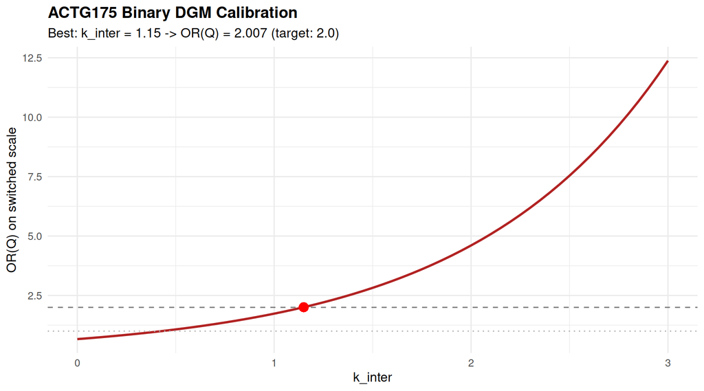

Calibration of k_inter: OR(Q) as a function of the interaction parameter.

```r
cal_grid <- seq(cal_k_grid_range[1], cal_k_grid_range[2], by = cal_grid_step)
cal_or_Q <- vapply(cal_grid, function(k) {
  d <- generate_glm_dgm(
    data = actg_df, factor_vars = dgm_factor_vars,
    outcome_var = "y_binary", treatment_var = "treat",
    outcome_type = "binary", subgroup_vars = dgm_subgroup_vars,
    subgroup_cuts = dgm_subgroup_cuts, model = "alt",
    k_inter = k, n_super = dgm_n_super, seed = sim_seed
  )
  d$hazard_ratios$harm_subgroup
}, numeric(1))

cal_df <- data.frame(k_inter = cal_grid, or_Q = cal_or_Q)
best_k <- dgm_calibrated$model_params$k_inter

ggplot(cal_df, aes(x = k_inter, y = or_Q)) +
  geom_line(linewidth = 1, colour = "firebrick") +
  geom_hline(yintercept = cal_target_or, linetype = "dashed",
             colour = "grey50") +
  geom_hline(yintercept = 1.0, linetype = "dotted",
             colour = "grey70") +
  geom_point(
    data = data.frame(k_inter = best_k,
                      or_Q = dgm_calibrated$hazard_ratios$harm_subgroup),
    colour = "red", size = 4, shape = 16
  ) +
  labs(
    x = "k_inter",
    y = "OR(Q) on switched scale",
    title = "ACTG175 Binary DGM Calibration",
    subtitle = sprintf(
      "Best: k_inter = %.2f -> OR(Q) = %.3f (target: %.1f)",
      best_k, dgm_calibrated$hazard_ratios$harm_subgroup, cal_target_or
    )
  ) +
  theme_minimal(base_size = 12) +
  theme(plot.title = element_text(face = "bold"))
```

## 4.3 Step 3: Create Null DGM

Under `model = "null"`, the treatment effect is **homogeneous** across all patients (no treatment effect heterogeneity). Per León et al. (2024, Section 3), $Q = \emptyset$ and $Q^c$ is the ITT population. The `flag_harm` column is retained as a structural label in the simulated data (marking $z_1 = 1 \cap z_2 = 1$) but has **no treatment-effect meaning**: there is no true benefit subgroup under this hypothesis.

```r
t0 <- proc.time()[3]

dgm_null <- generate_glm_dgm(
  data          = actg_df,
  factor_vars   = dgm_factor_vars,
  outcome_var   = "y_binary",
  treatment_var = "treat",
  outcome_type  = "binary",
  subgroup_vars = dgm_subgroup_vars,
  subgroup_cuts = dgm_subgroup_cuts,
  model         = "null",
  n_super       = dgm_n_super,
  seed          = sim_seed,
  verbose       = TRUE
)
```

```
#> === generate_glm_dgm() ===
#>   outcome_type:   binary
#>   effect_measure: OR
#>   model:          null
#>   k_inter:        0.000
#>   k_treat:        1.000
#>   n_super:        5000
#>   n observations: 1083
#>   Dropped single-level factors: z4
#>
#> === Subgroup Definitions ===
#>    z1 == 1
#>     Proportion in subgroup: 0.488
#>    z2 == 1
#>     Proportion in subgroup: 0.75
#>
#> Overall subgroup (all conditions met):
#>   Size: 382 out of 1083
#>   Proportion: 0.353
#>
#> Baseline GLM fit (no interaction):
#>   AIC: 1411.2
#>   Treatment coefficient: -0.4269 (OR = 0.653)
#>   Interaction shift (k_inter): 0.0000 (null model: forced to 0)
#>
#> === DGM Summary ===
#>   Effect(Q):   NA  (OR)
#>   Effect(Qc):  0.6678  (OR)
#>   Effect(ITT): 0.6678  (OR)
#>   Subgroup prevalence: 0.0%
```

```r
cat("\n=== ACTG175 Null DGM ===\n")
```

```
#>
#> === ACTG175 Null DGM ===
```

```r
cat("  OR(ITT):", round(dgm_null$hazard_ratios$overall, 3), "\n")
```

```
#>   OR(ITT): 0.668
```

```r
cat("  OR(Q):  ", round(dgm_null$hazard_ratios$harm_subgroup, 3), "\n")
```

```
#>   OR(Q):   NA
```

```r
cat("  OR(Qc): ", round(dgm_null$hazard_ratios$no_harm_subgroup, 3), "\n")
```

```
#>   OR(Qc):  0.668
```

```r
timings$dgm_null <- proc.time()[3] - t0
```

# 5 Single-Data Analysis

```r
t0 <- proc.time()[3]

cat("=", rep("=", 60), "\n", sep = "")
cat("  ForestSearch on ACTG175 observed data\n")
```

```
#>   ForestSearch on ACTG175 observed data
```

```r
cat("  outcome_type = 'binary', effect_measure = 'OR'\n")
```

```
#>   outcome_type = 'binary', effect_measure = 'OR'
```

```r
cat("  Treatment: switched (ddI = 1, ZDV+ddI = 0)\n")
```

```
#>   Treatment: switched (ddI = 1, ZDV+ddI = 0)
```

```r
cat("  Y = I(cd420 > cd40) = improvement\n")
```

```
#>   Y = I(cd420 > cd40) = improvement
```

```r
cat("  Thresholds: c1 =", fs_or_threshold,
    " c2 =", fs_or_consistency, "\n")
```

```
#>   Thresholds: c1 = 1.667  c2 = 1.25
```

```r
cat("=", rep("=", 60), "\n\n", sep = "")
confounders_actg <- dgm_calibrated$factor_vars

fs_actg <- forestsearch(
  df.analysis      = actg_df,
  confounders.name = confounders_actg,
  outcome.name     = "y_binary",
  event.name       = "y_binary",
  treat.name       = "treat",
  id.name          = "id",
  outcome_type     = "binary",
  effect_measure   = "OR",
  seedit           = fs_seedit,
  n.min            = fs_n_min,
  d0.min           = fs_d0_min,
  d1.min           = fs_d1_min,
  hr.threshold     = fs_or_threshold,
  hr.consistency   = fs_or_consistency,
  pconsistency.threshold = fs_pconsistency,
  fs.splits        = fs_splits,
  maxk             = fs_maxk,
  use_lasso        = fs_use_lasso,
  use_grf          = fs_use_grf,
  is.RCT           = fs_is_rct,
  vi.grf.min       = fs_vi_grf_min,
  details          = TRUE,
  quiet            = FALSE,
  parallel_args    = list(
    plan = "sequential", workers = 1, show_message = FALSE
  )
)
```

```
#>
#> [forestsearch] Subgroup Identification Configuration
#>   Outcome type:   binary
#>   Effect measure: OR (Odds Ratio)
#>   Scale:          log (ratio)
#>
#>   Screening:      OR >= 1.67 (log: 0.5110)
#>   Consistency:    OR >= 1.25 (log: 0.2231)
#>   Consistency rate threshold: 90%
#>
#>   Interpretation:
#>     Candidates: subgroup OR >= 1.67
#>     Splits:     each split OR >= 1.25
```

```
#>   Search Alignment Diagnostic
```

```
#>
#>   Outcome:    y_binary (binary)
```

```
#>   Treatment:  treat
```

```
#>   Measure:    Odds Ratio (OR) -- estimator sees Y as-is (no flip)
```

```
#>
#>   ForestSearch searches for:
#>     Subgroups where treat increases P(y_binary=1)
#>     (OR >= threshold on the ORIGINAL outcome scale)
```

```
#>
#>   Thresholds:
#>     Screening: OR >= 1.667 in the candidate subgroup
#>     Consistency: OR >= 1.250 in each bootstrap split
```

```
#>
#>   Variable screening:
```

```
#>     LASSO: LASSO screening: DISABLED
```

```
#>     GRF:   GRF sees 1-y_binary (flipped for causal_forest).
#>     Positive CATE = treatment REDUCES y_binary = treatment HELPS.
```

```
#>
#>   No alignment concerns detected.
```

```
#> GRF subgroup: z2 <= 0 & z1 <= 0
#> GRF cuts identified: 2
#>   Cuts: z2 <= 0, z1 <= 0
#> Candidate factors: 11
#>  [1] "z1"  "z2"  "z3"  "z5"  "z6"  "z7"  "z8"  "z9"  "z10" "z11" "z12"
#> Number of possible configurations (<= maxk): maxk = 2 , # combinations = 253
#> Events criteria: control >= 12 , treatment >= 12
#> Sample size criteria: n >= 60
#> Subgroup search completed in 0.01 minutes
#>
#> --- Filtering Summary ---
#>   Combinations evaluated: 253
#>   Passed variance check: 242
#>   Passed prevalence (>= 0.025 ): 242
#>   Passed redundancy check: 237
#>   Passed event counts (d0>= 12 , d1>= 12 ): 228
#>   Passed sample size (n>= 60 ): 210
#>   Cox model fit successfully: 210
#>   Passed HR threshold (>= 0.5110256 ): 0
#> -------------------------
#>
#> NO subgroup candidates found
```

```r
timings$single_data <- proc.time()[3] - t0
```

## 5.1 Examine Result

```r
cat("\n=== ForestSearch Result ===\n")
```

```
#>
#> === ForestSearch Result ===
```

```r
if (!is.null(fs_actg$grp.consistency)) {
  sg <- fs_actg$grp.consistency$sg.harm.id
  if (!is.null(sg) && length(sg) > 0 && !all(is.na(sg))) {
    cat("Subgroup identified:", paste(sg, collapse = " & "), "\n")

    df_est <- fs_actg$df.est
    in_H  <- df_est$treat.recommend == 0
    in_Hc <- df_est$treat.recommend == 1

    cat(sprintf("  Size(H): %d,  Size(Hc): %d\n",
        sum(in_H), sum(in_Hc)))

    if (sum(in_H) >= 10) {
      fit_H <- glm(y_binary ~ treat, data = df_est[in_H, ],
                    family = binomial)
      or_H <- exp(coef(fit_H)["treat"])
      cat(sprintf("  OR(H, switched):  %.3f  (inverted: %.3f)\n",
          or_H, 1/or_H))
    }
    if (sum(in_Hc) >= 10) {
      fit_Hc <- glm(y_binary ~ treat, data = df_est[in_Hc, ],
                     family = binomial)
      or_Hc <- exp(coef(fit_Hc)["treat"])
      cat(sprintf("  OR(Hc, switched): %.3f  (inverted: %.3f)\n",
          or_Hc, 1/or_Hc))
    }

    fit_itt <- glm(y_binary ~ treat, data = df_est, family = binomial)
    cat(sprintf("  OR(ITT, switched): %.3f\n",
        exp(coef(fit_itt)["treat"])))

    true_H <- df_est$flag_harm_ref == 1
    if (sum(true_H) > 0 && sum(in_H) > 0) {
      tp <- sum(in_H & true_H);  fp <- sum(in_H & !true_H)
      fn <- sum(!in_H & true_H); tn <- sum(!in_H & !true_H)
      cat(sprintf("\n  Classification vs true Q:\n"))
      cat(sprintf("    TP: %d  FP: %d  FN: %d  TN: %d\n",
          tp, fp, fn, tn))
      cat(sprintf("    Sens: %.3f  Spec: %.3f  PPV: %.3f\n",
          tp/(tp+fn), tn/(tn+fp), tp/(tp+fp)))
    }
  } else {
    cat("No subgroup identified by ForestSearch.\n")
  }
} else {
  cat("ForestSearch did not return grp.consistency.\n")
}
```

```
#> ForestSearch did not return grp.consistency.
```

```r
cat(sprintf("\nSingle-data analysis: %.1f sec\n", timings$single_data))
```

```
#>
#> Single-data analysis: 1.3 sec
```

## 5.2 GRF Standalone on Observed Data

```r
grf_actg <- grf.subg.harm.glm(
  data             = actg_df,
  confounders.name = confounders_actg,
  outcome.name     = "y_binary",
  treat.name       = "treat",
  id.name          = "id",
  outcome_type     = "binary",
  effect_measure   = "OR",
  dmin.grf         = grf_dmin,
  maxdepth         = grf_maxdepth,
  RCT              = TRUE,
  sg.criterion     = grf_sg_criterion,
  details          = TRUE
)

if (!is.null(grf_actg$sg.harm.id) && length(grf_actg$sg.harm.id) > 0) {
  cat("GRF subgroup:", paste(grf_actg$sg.harm.id, collapse = " & "), "\n")
  grf_H <- grf_actg$data$treat.recommend == 0
  cat(sprintf("  Size(H): %d,  Size(Hc): %d\n",
      sum(grf_H), sum(!grf_H)))
} else {
  cat("GRF: no subgroup identified.\n")
}
```

```
#> GRF subgroup: z2 <= 0 & z1 <= 0
#>   Size(H): 959,  Size(Hc): 124
```

## 5.3 FS vs GRF Concordance on Observed Data

When a method does not detect a subgroup, its classification is “all subjects to $Q^c$” (`treat.recommend = 1` for everyone). `compare_fs_subgroups()` handles this automatically — no manual fallback is needed.

```r
sg_compare <- compare_fs_subgroups(
  fs1                = fs_actg,
  fs2                = grf_actg,
  label1             = "ForestSearch",
  label2             = "GRF Standalone",
  id.name            = "id",
  subgroup_notation  = sg_notation,
  title              = "FS vs GRF: Subgroup Membership Concordance",
  subtitle           = "ACTG175 observed data (binary benefit search)",
  font_size          = 13
)

sg_compare$table
```

**FS vs GRF: Subgroup Membership Concordance**

ACTG175 observed data (binary benefit search)

| ForestSearch | GRF Standalone Q (Benefit) | GRF Standalone Qᶜ (No benefit) | Total |  |
| --- | --- | --- | --- | --- |
| Q (Benefit) | 0 | 0 |  | 0 |
| Qᶜ (No benefit) | 959 | 124 | 1083 |  |
| Total | 959 | 124 | 1083 |  |

**Agreement:** 124 / 1083 (11.4%) **Cohen’s κ:** 0.000 **ForestSearch H:** (none identified) **GRF Standalone H:** z2 <= 0 & z1 <= 0

```r
cat("Concordance statistics:\n")
```

```
#> Concordance statistics:
```

```r
cat(sprintf("  Agreement: %.1f%%\n",
    100 * sg_compare$concordance$agreement))
```

```
#>   Agreement: 11.4%
```

```r
cat(sprintf("  Cohen's kappa: %.3f\n",
    sg_compare$concordance$kappa))
```

```
#>   Cohen's kappa: 0.000
```

```r
cat(sprintf("  Concordant: %d / Discordant: %d / Total: %d\n",
    sg_compare$concordance$n_agree,
    sg_compare$concordance$n_disagree,
    sg_compare$concordance$n_total))
```

```
#>   Concordant: 124 / Discordant: 959 / Total: 1083
```

# 6 Single Trial Simulation

Before the full simulation study, verify that `simulate_from_glm_dgm()` and `run_simulation_analysis()` work end-to-end on a single replicate.

```r
t0 <- proc.time()[3]

# Simulate one trial from the calibrated DGM
df_single <- simulate_from_glm_dgm(
  dgm  = dgm_calibrated,
  n    = sim_n_sample,
  seed = sim_seed + 1L
)

cat(sprintf("Single trial: N = %d, response rate = %.1f%%\n",
    nrow(df_single), 100 * mean(df_single$y_sim)))
```

```
#> Single trial: N = 1000, response rate = 65.9%
```

```r
cat(sprintf("  treat allocation: %.1f%%\n",
    100 * mean(df_single$treat_sim)))
```

```
#>   treat allocation: 49.1%
```

```r
cat(sprintf("  Q prevalence: %.1f%%\n",
    100 * mean(df_single$flag_harm)))
```

```
#>   Q prevalence: 35.5%
```

```r
# Verify OR in the simulated data
fit_single <- glm(y_sim ~ treat_sim, data = df_single, family = binomial)
cat(sprintf("  Simulated ITT OR: %.3f (DGM: %.3f)\n",
    exp(coef(fit_single)["treat_sim"]),
    dgm_calibrated$hazard_ratios$overall))
```

```
#>   Simulated ITT OR: 0.858 (DGM: 0.919)
```

```r
timings$single_trial <- proc.time()[3] - t0
```

# 7 Running Simulation Studies

## 7.1 Setup

```r
plan(multisession, workers = n_workers)
cat("Using", n_workers, "parallel workers\n")
```

```
#> Using 115 parallel workers
```

```r
# -- Candidate variable set ----------------------------------------------------
confounders_actg <- dgm_calibrated$factor_vars

# -- ForestSearch parameters ---------------------------------------------------
fs_params <- list(
  # Column name mappings
  outcome.name           = "y_sim",
  event.name             = "y_sim",
  treat.name             = "treat_sim",
  id.name                = "id",

  # GLM pipeline (auto-injected from DGM, but explicit for clarity)
  outcome_type           = "binary",
  effect_measure         = "OR",

  # Variable screening
  use_lasso              = fs_use_lasso,
  use_grf                = fs_use_grf,

  # Subgroup detection thresholds
  # Note: hr.threshold/hr.consistency are the generic ForestSearch
  # parameter names regardless of endpoint type. For binary outcomes,
  # these represent OR thresholds on the switched scale.
  hr.threshold           = fs_or_threshold,
  hr.consistency         = fs_or_consistency,
  pconsistency.threshold = fs_pconsistency,

  # Computational constraints
  fs.splits              = fs_splits,
  n.min                  = fs_n_min,
  d0.min                 = fs_d0_min,
  d1.min                 = fs_d1_min,
  maxk                   = fs_maxk,
  vi.grf.min             = fs_vi_grf_min,
  seedit                 = fs_seedit,

  # GRF tuning (applies to ForestSearch's internal GRF pre-screening)
  tune_grf               = grf_tune,

  # Inner parallelism: sequential within each worker
  parallel_args          = list(
    plan = "sequential", workers = 1, show_message = FALSE
  )
)

# -- GRF standalone parameter overrides ----------------------------------------
grf_params <- list(
  dmin.grf     = grf_dmin,
  maxdepth     = grf_maxdepth,
  sg.criterion = grf_sg_criterion,
  tune_grf     = grf_tune
)
```

## 7.2 Alternative Hypothesis Simulations

```r
cat("Running", nsims_alt, "simulations under H1...\n")
```

```
#> Running 5000 simulations under H1...
```

```r
t0 <- proc.time()[3]

results_alt_raw <- foreach(
  sim = seq_len(nsims_alt),
  .errorhandling = "pass",
  .options.future = list(
    packages = c("forestsearch", "survival", "data.table", "future"),
    seed = TRUE
  )
) %dofuture% {
  future::plan("sequential")
  run_simulation_analysis(
    sim_id           = sim,
    dgm              = dgm_calibrated,
    n_sample         = sim_n_sample,
    confounders_base = confounders_actg,
    n_add_noise      = sim_n_noise,
    run_fs           = run_fs,
    run_fs_grf       = run_fs_grf,
    run_grf          = run_grf,
    fs_params        = fs_params,
    grf_params       = grf_params,
    verbose          = FALSE
  )
}

timings$sims_alt <- proc.time()[3] - t0

# Post-hoc failure accounting
results_alt <- collect_results(results_alt_raw, "H1 alt")
n_failed_alt <- attr(results_alt, "n_failed")

cat("Completed in", round(timings$sims_alt / 60, 1), "minutes\n")
```

```
#> Completed in 13.7 minutes
```

```r
cat("Results:", nrow(results_alt), "rows\n")
```

```
#> Results: 10000 rows
```

```r
if (n_failed_alt > 0) cat(sprintf("  *** %d FAILED ***\n", n_failed_alt))
if (nrow(results_alt) > 0) {
  cat(sprintf("Detection rate: %.1f%%\n",
      100 * mean(results_alt$any.H[results_alt$analysis == "FS"])))
} else {
  cat("All simulations failed — see error messages above.\n")
  cat("Common causes:\n")
  cat("  1. devtools::document() -> devtools::install() -> restart R needed\n")
  cat("  2. Package version mismatch between interactive and worker sessions\n")
}
```

```
#> Detection rate: 74.1%
```

## 7.3 Null Hypothesis Simulations

```r
# Reset worker pool to prevent memory accumulation from alt sims
plan(sequential); gc(verbose = FALSE); Sys.sleep(1)
```

```
#>            used  (Mb) gc trigger  (Mb) max used  (Mb)
#> Ncells  3453862 184.5    6668367 356.2  4607578 246.1
#> Vcells 11760687  89.8   21728944 165.8 17021009 129.9
```

```r
plan(multisession, workers = n_workers)
```

```r
cat("Running", nsims_null, "simulations under H0...\n")
```

```
#> Running 20000 simulations under H0...
```

```r
t0 <- proc.time()[3]

results_null_raw <- foreach(
  sim = seq_len(nsims_null),
  .errorhandling = "pass",
  .options.future = list(
    packages = c("forestsearch", "survival", "data.table", "future"),
    seed = TRUE
  )
) %dofuture% {
  future::plan("sequential")
  run_simulation_analysis(
    sim_id           = sim,
    dgm              = dgm_null,
    n_sample         = sim_n_sample,
    confounders_base = confounders_actg,
    n_add_noise      = sim_n_noise,
    run_fs           = run_fs,
    run_fs_grf       = run_fs_grf,
    run_grf          = run_grf,
    fs_params        = fs_params,
    grf_params       = grf_params,
    verbose          = FALSE
  )
}

timings$sims_null <- proc.time()[3] - t0

results_null <- collect_results(results_null_raw, "H0 null")
n_failed_null <- attr(results_null, "n_failed")

cat("Completed in", round(timings$sims_null / 60, 1), "minutes\n")
```

```
#> Completed in 34.9 minutes
```

```r
if (n_failed_null > 0) cat(sprintf("  *** %d FAILED ***\n", n_failed_null))
cat(sprintf("False positive rate: %.1f%%\n",
    100 * mean(results_null$any.H[results_null$analysis == "FS"])))
```

```
#> False positive rate: 4.3%
```

```r
plan(sequential)
```

```r
if (save_results) {
  if (!dir.exists(output_dir)) dir.create(output_dir, recursive = TRUE)

  bundle <- list(
    # -- Core results ----------------------------------------------------------
    results_alt  = results_alt,
    results_null = results_null,

    # -- DGM objects -----------------------------------------------------------
    dgm_calibrated = dgm_calibrated,
    dgm_null       = dgm_null,

    # -- Simulation configuration ----------------------------------------------
    config = list(
      nsims_alt    = nsims_alt,
      nsims_null   = nsims_null,
      n_sample     = sim_n_sample,
      n_noise      = sim_n_noise,
      sim_seed     = sim_seed,
      n_workers    = n_workers,
      outcome_type = "binary",
      effect_measure = "OR"
    ),

    # -- ForestSearch parameters -----------------------------------------------
    fs_params = fs_params,

    # -- GRF parameters --------------------------------------------------------
    grf_params = grf_params,

    # -- DGM true effects (convenience) ----------------------------------------
    true_effects = list(
      or_Q    = dgm_calibrated$hazard_ratios$harm_subgroup,
      or_Qc   = dgm_calibrated$hazard_ratios$no_harm_subgroup,
      or_ITT  = dgm_calibrated$hazard_ratios$overall,
      k_inter = dgm_calibrated$model_params$k_inter
    ),

    # -- Provenance ------------------------------------------------------------
    timestamp   = Sys.time(),
    R_version   = R.version.string,
    fs_version  = tryCatch(
      as.character(utils::packageVersion("forestsearch")),
      error = function(e) "unknown"
    ),
    timings     = timings,

    # -- Failure accounting ----------------------------------------------------
    n_failed_alt  = n_failed_alt,
    n_failed_null = n_failed_null
  )

  filename <- sprintf("actg175_binary_benefit_simulations_%dalts_%dnulls.rds",
                       nsims_alt, nsims_null)
  path <- file.path(output_dir, filename)
  saveRDS(bundle, path)

  cat(sprintf("Results saved: %s\n", path))
  cat(sprintf("  Size: %.1f KB\n", file.size(path) / 1024))
  cat(sprintf("  Alt sims: %d completed (%d failed)\n",
      nsims_alt - n_failed_alt, n_failed_alt))
  cat(sprintf("  Null sims: %d completed (%d failed)\n",
      nsims_null - n_failed_null, n_failed_null))
  cat(sprintf("  OR(Q) = %.3f, OR(Qc) = %.3f\n",
      dgm_calibrated$hazard_ratios$harm_subgroup,
      dgm_calibrated$hazard_ratios$no_harm_subgroup))
} else {
  cat("save_results = FALSE; skipping save.\n")
}
```

```
#> Results saved: _data/actg175_binary_benefit_simulations_5000alts_20000nulls.rds
#>   Size: 3152.7 KB
#>   Alt sims: 5000 completed (0 failed)
#>   Null sims: 20000 completed (0 failed)
#>   OR(Q) = 2.007, OR(Qc) = 0.668
```

# 8 Results

## 8.1 Metrics Glossary

Classification metrics follow the definitions in León et al. (2024, Section 3) adapted for the benefit search.

### 8.1.1 Detection

**Found** ($\text{any}(Q)$): proportion of simulations where the method identifies *any* benefit subgroup ($\texttt{any.H} = 1$).

- **Under H1** (alternative): $Q$ exists with a differential treatment effect. $\text{any}(Q)$ is **detection power**.
- **Under H0** (null): $Q = \emptyset$ and $Q^c$ is the ITT population. $\text{any}(Q)$ is the **false positive rate (FPR)** for falsely declaring that a benefit subgroup exists.

### 8.1.2 Classification Under H1

Under the alternative, the true benefit subgroup $Q$ exists ($Q = \{z_1 = 1 \cap z_2 = 1\}$, prevalence $\approx 34\%$) with a genuinely different treatment effect. Following León et al. (2024, Section 3), define for estimated subgroup $\hat{Q}$:

$$\text{sens}(\hat{Q}) = \frac{\#\{i \in \hat{Q} \cap Q\}}{\#\{i \in Q\}},
\quad
\text{ppv}(\hat{Q}) = \frac{\#\{i \in \hat{Q} \cap Q\}}{\#\{i \in \hat{Q}\}},$$

with analogous measures for the complement $\hat{Q}^c$.

The operating-characteristics tables report these as:

| Table column | León et al. notation | Interpretation |
| --- | --- | --- |
| **Sen** | $\text{sens}(\hat{Q})$ | Fraction of true $Q$ captured by $\hat{Q}$ |
| **Spec** | $\text{sens}(\hat{Q}^c)$ | Fraction of true $Q^c$ correctly in $\hat{Q}^c$ |
| **PPV** | $\text{ppv}(\hat{Q})$ | Fraction of $\hat{Q}$ truly in $Q$ |
| **NPV** | $\text{ppv}(\hat{Q}^c)$ | Fraction of $\hat{Q}^c$ truly in $Q^c$ |

Classification metrics are averaged across **all** simulations (León et al. 2024, Table 1). When no subgroup is detected ($\hat{Q} = \emptyset$), the simulation contributes $\text{sens}(\hat{Q}) = 0$ and $\text{ppv}(\hat{Q}) = 0$ (since no member of $Q$ is captured and no subjects are assigned to $\hat{Q}$). This convention is implemented at the source in `run_simulation_analysis()`, matching the original `fs.estimates.out()` function used in León et al. (2024).

### 8.1.3 Classification Under H0

Under the null, $Q = \emptyset$ — no subgroup with a differential treatment effect exists. The complement $Q^c$ is the entire ITT population. Per León et al. (2024, Section 3), $\text{sens}(\hat{Q})$ is **undefined** (shown as “—” in the table) and $\text{ppv}(\hat{Q}) \equiv 0$. For the complement, $\text{sens}(\hat{Q}^c) = |\hat{Q}^c|/N$ and $\text{ppv}(\hat{Q}^c) = 1$ since $Q^c$ = ITT.

The only operationally meaningful metric under H0 is the **detection rate (FPR)**.

### 8.1.4 Effect Estimates

All effect estimates are displayed on the **original** treatment scale (OR $< 1$ = benefit from ZDV+ddI) via `subgroup_notation = "benefit"`.

## 8.2 Operating Characteristics Under H1

```r
t0 <- proc.time()[3]

format_oc_results(
  results_alt,
  metrics   = c("detection", "classification"),
  digits    = 2,
  digits_hr = 2,
  title     = "ACTG175 Binary: Identification (Benefit Search)",
  subtitle  = sprintf(
    "n = %d, %d sims, OR(Q) = %.2f, OR(Qc) = %.2f (switched)",
    sim_n_sample, nsims_alt,
    dgm_calibrated$hazard_ratios$harm_subgroup,
    dgm_calibrated$hazard_ratios$no_harm_subgroup
  ),
  subgroup_notation = sg_notation
)
```

ACTG175 Binary: Identification (Benefit Search)

n = 1000, 5000 sims, OR(Q) = 2.01, OR(Qc) = 0.67 (switched)

| Method | Sims | Found | Classification Sen | Classification Spec | Classification PPV | Classification NPV |
| --- | --- | --- | --- | --- | --- | --- |
| FS | 5000 | 0.74 | 0.42 | 0.88 | 0.59 | 0.87 |
| GRF | 5000 | 0.72 | 0.65 | 0.79 | 0.54 | 0.96 |

```r
build_estimation_table(
  results         = results_alt,
  dgm             = dgm_calibrated,
  analysis_method = "FS",
  subtitle = sprintf(
    "ACTG175 Binary DGM | n = %d, %d sims",
    sim_n_sample, nsims_alt
  ),
  font_size = 16,
  subgroup_notation = sg_notation
)
```

Estimation Properties

ACTG175 Binary DGM | n = 1000, 5000 sims (FS: 3705/5000 (74%) estimable)

|  | Avg | SD | Min | Max | b† (%) |
| --- | --- | --- | --- | --- | --- |
| Q̂: 3705 estimable, avg \|Q̂\| = 219, θ†(Q) = 0.5 |  |  |  |  |  |
| θ̂(Q̂) | 0.36 | 0.10 | 0.00 | 0.57 | -28.36 |
| Q̂ᶜ: avg \|Q̂ᶜ\| = 781, θ†(Qᶜ) = 1.5 |  |  |  |  |  |
| θ̂(Q̂ᶜ) | 1.37 | 0.28 | 0.67 | 2.51 | -8.46 |

θ̂(Q̂) = plugin Cox HR in identified subgroup; θ̂*(Q̂) = bootstrap bias-corrected; âhr(Q̂) = average hazard ratio in identified subgroup; b† = bias relative to marginal HR θ† (causal truth)

```r
if ("GRF" %in% unique(results_alt$analysis)) {
  build_estimation_table(
    results         = results_alt,
    dgm             = dgm_calibrated,
    analysis_method = "GRF",
    subtitle = sprintf(
      "ACTG175 Binary DGM (GRF, dmin=%.2f) | n = %d, %d sims",
      grf_dmin, sim_n_sample, nsims_alt
    ),
    font_size = 16,
    subgroup_notation = sg_notation
  )
}
```

Estimation Properties

ACTG175 Binary DGM (GRF, dmin=0.10) | n = 1000, 5000 sims (GRF: 3592/5000 (72%) estimable)

|  | Avg | SD | Min | Max | b† (%) |
| --- | --- | --- | --- | --- | --- |
| Q̂: 3592 estimable, avg \|Q̂\| = 419, θ†(Q) = 0.5 |  |  |  |  |  |
| θ̂(Q̂) | 0.51 | 0.09 | 0.20 | 0.75 | 1.88 |
| Q̂ᶜ: avg \|Q̂ᶜ\| = 581, θ†(Qᶜ) = 1.5 |  |  |  |  |  |
| θ̂(Q̂ᶜ) | 1.71 | 0.27 | 0.92 | 3.07 | 14.53 |

θ̂(Q̂) = plugin Cox HR in identified subgroup; θ̂*(Q̂) = bootstrap bias-corrected; âhr(Q̂) = average hazard ratio in identified subgroup; b† = bias relative to marginal HR θ† (causal truth)

```r
timings$report_alt <- proc.time()[3] - t0
```

### 8.2.1 Interpretation

```r
interpret_estimation_table(
  results_alt, dgm_calibrated,
  analysis_method = "FS",
  scenario = "alt",
  subgroup_notation = sg_notation
)
```

Under the alternative hypothesis (true HR(Q) = 0.5, true HR(Qc) = 1.5), 3705 of 5000 simulations (74.1%) identified a subgroup using FS. The identified subgroup averaged 219 patients (complement: 781).

The naive Cox HR in the identified subgroup averaged 0.36 (SD = 0.1), corresponding to -28.4% relative bias versus the true HR(Q) = 0.5. In the complement, the estimate averaged 1.37 (-8.5% bias vs. true HR(Qc) = 1.5).

## 8.3 Operating Characteristics Under H0

```r
format_oc_results(
  results_null,
  metrics  = c("detection", "classification"),
  digits   = 2,
  title    = "ACTG175 Binary: Type I Error (Null)",
  subtitle = sprintf(
    "n = %d, %d sims, OR(ITT) = %.2f (switched)",
    sim_n_sample, nsims_null,
    dgm_null$hazard_ratios$overall
  ),
  subgroup_notation = sg_notation
)
```

ACTG175 Binary: Type I Error (Null)

n = 1000, 20000 sims, OR(ITT) = 0.67 (switched)

| Method | Sims | Found | Classification Sen | Classification Spec | Classification PPV | Classification NPV |
| --- | --- | --- | --- | --- | --- | --- |
| FS | 20000 | 0.04 | - | 1.00 | 0.00 | 1.00 |
| GRF | 20000 | 0.29 | - | 0.96 | 0.00 | 1.00 |

**Note**

Under H0, $Q = \emptyset$. Sen is undefined (shown as “—”) and PPV $\equiv 0$ (León et al. 2024, Section 3). The detection rate (Found) is the false positive rate.

## 8.4 Classification Table

```r
build_classification_table(
  scenario_results = list(
    null = list(
      results  = results_null,
      label    = "ACTG-bin",
      n_sample = sim_n_sample,
      dgm      = dgm_null,
      hypothesis = "null"
    ),
    alt = list(
      results  = results_alt,
      label    = "ACTG-bin",
      n_sample = sim_n_sample,
      dgm      = dgm_calibrated,
      hypothesis = "alt"
    )
  ),
  analyses = sort(unique(c(
    unique(results_null$analysis),
    unique(results_alt$analysis)
  ))),
  digits    = 2,
  font_size = 16,
  title     = "ACTG175 Binary: Subgroup Identification and Classification",
  n_sims    = nsims_alt,
  subgroup_notation = sg_notation
)
```

ACTG175 Binary: Subgroup Identification and Classification

|  | FS | GRF |
| --- | --- | --- |
| ACTG-bin Null: N=1000, theta(ITT) = 1.5 |  |  |
| any(Q) | 0.04 | 0.29 |
| sens(Qc) | 1.00 | 0.96 |
| ppv(Qc) | 1.00 | 1.00 |
| avg\|Q\| | 93.00 | 140.00 |
| ACTG-bin Alt: N=1000, p_Q=34%, theta(Q)=0.5, theta(Qc)=1.5, theta(ITT)=1.09 |  |  |
| any(Q) | 0.74 | 0.72 |
| sens(Q) | 0.42 | 0.65 |
| sens(Qc) | 0.88 | 0.79 |
| ppv(Q) | 0.59 | 0.54 |
| ppv(Qc) | 0.87 | 0.96 |
| avg\|Q\| | 219.00 | 419.00 |

# 9 Timing Summary

```r
timings$total <- (proc.time() - t_vignette_start)["elapsed"]

timing_df <- data.frame(
  Step = c(names(timings)),
  Seconds = round(unlist(timings), 1),
  Minutes = round(unlist(timings) / 60, 2)
)

timing_df |>
  gt::gt() |>
  gt::tab_header(title = "Computation Timing") |>
  gt::tab_style(
    style = gt::cell_text(weight = "bold"),
    locations = gt::cells_body(rows = Step == "total")
  )
```

Computation Timing

| Step | Seconds | Minutes |
| --- | --- | --- |
| data_prep | 0.0 | 0.00 |
| dgm_init | 0.0 | 0.00 |
| calibrate | 1.4 | 0.02 |
| dgm_null | 0.0 | 0.00 |
| single_data | 1.3 | 0.02 |
| single_trial | 0.0 | 0.00 |
| sims_alt | 819.0 | 13.65 |
| sims_null | 2096.3 | 34.94 |
| report_alt | 0.2 | 0.00 |
| total | 2931.2 | 48.85 |

### 9.0.1 Projection for Production Runs

```r
# Per-replicate cost (simulation loop only)
time_per_alt  <- timings$sims_alt / nsims_alt
time_per_null <- timings$sims_null / nsims_null

# prod_alt and prod_null defined in setup chunk
proj_alt  <- time_per_alt * prod_alt
proj_null <- time_per_null * prod_null
proj_other <- timings$total - timings$sims_alt - timings$sims_null
proj_total <- proj_alt + proj_null + proj_other

cat(sprintf("Current run: %d alt + %d null on %d workers\n",
    nsims_alt, nsims_null, n_workers))
```

```
#> Current run: 5000 alt + 20000 null on 115 workers
```

```r
cat(sprintf("  Per-replicate: %.1f sec (alt), %.1f sec (null)\n",
    time_per_alt, time_per_null))
```

```
#>   Per-replicate: 0.2 sec (alt), 0.1 sec (null)
```

```r
cat(sprintf("\nProjected for %d alt + %d null:\n", prod_alt, prod_null))
```

```
#>
#> Projected for 5000 alt + 25000 null:
```

```r
cat(sprintf("  Alt sims:   %5.0f sec (%4.1f min)\n", proj_alt, proj_alt / 60))
```

```
#>   Alt sims:     819 sec (13.7 min)
```

```r
cat(sprintf("  Null sims:  %5.0f sec (%4.1f min)\n", proj_null, proj_null / 60))
```

```
#>   Null sims:   2620 sec (43.7 min)
```

```r
cat(sprintf("  Other:      %5.0f sec (%4.1f min)\n", proj_other, proj_other / 60))
```

```
#>   Other:         16 sec ( 0.3 min)
```

```r
cat(sprintf("  Total:      %5.0f sec (%4.1f min = %.1f hours)\n",
    proj_total, proj_total / 60, proj_total / 3600))
```

```
#>   Total:       3455 sec (57.6 min = 1.0 hours)
```

# 10 Discussion

## 10.2 Limitations

- The binary DGM is based on a logistic regression fitted to the observed ACTG175 data. The super-population preserves the empirical covariate distribution but assumes the logistic model is correctly specified.
- `k_inter` is a direct additive shift on the log-odds scale for Q members under treatment. Positive values increase the outcome for Q; negative values decrease it.

## 10.3 Reloading Saved Results

When `save_results = TRUE`, the simulation bundle is saved as an `.rds` file in the `_data/` directory. To reload for downstream analysis:

```r
bundle <- readRDS("_data/actg175_binary_simulations_200alts_200nulls.rds")

# Core results (data.tables)
results_alt  <- bundle$results_alt
results_null <- bundle$results_null

# DGM objects (class "glm_dgm")
dgm_cal  <- bundle$dgm_calibrated
dgm_null <- bundle$dgm_null

# True effects
bundle$true_effects$or_Q    # OR(Q) on switched scale
bundle$true_effects$k_inter # calibrated interaction shift

# Reproduce tables
format_oc_results(results_alt, ...)
build_estimation_table(results_alt, dgm = dgm_cal, ...)
```

# 11 Summary

**Compute summary metrics**

```r
mc_se <- function(p, n) sqrt(p * (1 - p) / n)
methods <- sort(unique(results_alt$analysis))

summ <- data.frame(Method = methods, stringsAsFactors = FALSE)
for (m in methods) {
  ra <- results_alt[results_alt$analysis == m, ]
  rn <- results_null[results_null$analysis == m, ]

  summ$alt_det[summ$Method == m]   <- mean(ra$any.H, na.rm = TRUE)
  summ$null_fpr[summ$Method == m]  <- mean(rn$any.H, na.rm = TRUE)
  summ$alt_sens[summ$Method == m]  <- mean(ra$sens, na.rm = TRUE)
  summ$alt_ppv[summ$Method == m]   <- mean(ra$ppv, na.rm = TRUE)
  summ$se_det[summ$Method == m]    <- mc_se(
    summ$alt_det[summ$Method == m], nrow(ra))
  summ$se_fpr[summ$Method == m]    <- mc_se(
    summ$null_fpr[summ$Method == m], nrow(rn))
}
```

## 11.1 FS vs GRF Classification Concordance Across Simulations

Per-subject classification concordance between ForestSearch and GRF is computed within each simulation replicate by `run_simulation_analysis()` and stored as `agree.FS.GRF` and `kappa.FS.GRF` columns. When a method does not detect a subgroup, it classifies all subjects to $Q^c$.

**Classification concordance**

```r
conc_col <- "agree.FS.GRF"
kappa_col <- "kappa.FS.GRF"

if (all(c(conc_col, kappa_col) %in% names(results_alt)) &&
    all(c("FS", "GRF") %in% methods)) {

  # One row per sim (take FS rows — concordance is per-sim, same on both)
  fs_alt <- results_alt[results_alt$analysis == "FS", ]
  grf_alt <- results_alt[results_alt$analysis == "GRF", ]

  cat(sprintf("=== FS vs GRF Classification Concordance (%d sims) ===\n\n",
      nrow(fs_alt)))
  cat(sprintf("  Mean agreement:  %.1f%% (SD: %.1f%%)\n",
      100 * mean(fs_alt[[conc_col]], na.rm = TRUE),
      100 * sd(fs_alt[[conc_col]], na.rm = TRUE)))
  cat(sprintf("  Mean kappa:      %.3f (SD: %.3f)\n",
      mean(fs_alt[[kappa_col]], na.rm = TRUE),
      sd(fs_alt[[kappa_col]], na.rm = TRUE)))
  cat(sprintf("  Median kappa:    %.3f\n\n",
      median(fs_alt[[kappa_col]], na.rm = TRUE)))

  # Detection patterns
  both   <- sum(fs_alt$any.H == 1 & grf_alt$any.H == 1)
  fs_only <- sum(fs_alt$any.H == 1 & grf_alt$any.H == 0)
  grf_only <- sum(fs_alt$any.H == 0 & grf_alt$any.H == 1)
  neither <- sum(fs_alt$any.H == 0 & grf_alt$any.H == 0)
  n <- nrow(fs_alt)

  cat("Detection patterns:\n")
  cat(sprintf("  Both detect:    %3d (%.0f%%)\n", both, 100 * both / n))
  cat(sprintf("  FS only:        %3d (%.0f%%)\n", fs_only, 100 * fs_only / n))
  cat(sprintf("  GRF only:       %3d (%.0f%%)\n", grf_only, 100 * grf_only / n))
  cat(sprintf("  Neither:        %3d (%.0f%%)\n", neither, 100 * neither / n))

  if (both > 0) {
    both_idx <- fs_alt$any.H == 1 & grf_alt$any.H == 1
    cat(sprintf("\nWhen both detect (n=%d):\n", both))
    cat(sprintf("  Mean agreement: %.1f%%\n",
        100 * mean(fs_alt[[conc_col]][both_idx], na.rm = TRUE)))
    cat(sprintf("  Mean kappa:     %.3f\n",
        mean(fs_alt[[kappa_col]][both_idx], na.rm = TRUE)))
  }
} else {
  cat("Concordance columns not found in results.\n")
  cat("Ensure run_simulation_analysis() was called with run_fs=TRUE and run_grf=TRUE.\n")
}
```

```
#> === FS vs GRF Classification Concordance (5000 sims) ===
#>
#>   Mean agreement:  80.3% (SD: 17.1%)
#>   Mean kappa:      0.491 (SD: 0.405)
#>   Median kappa:    0.429
#>
#> Detection patterns:
#>   Both detect:    3162 (63%)
#>   FS only:        543 (11%)
#>   GRF only:       430 (9%)
#>   Neither:        865 (17%)
#>
#> When both detect (n=3162):
#>   Mean agreement: 77.0%
#>   Mean kappa:     0.503
```

## 11.2 Key Findings

```r
cat(sprintf("**Simulation budget**: %d alt + %d null sims.\n\n", nsims_alt, nsims_null))
```

**Simulation budget**: 5000 alt + 20000 null sims.

```r
for (m in methods) {
  s <- summ[summ$Method == m, ]
  cat(sprintf("- **%s**: Detection = %.1f%%, FPR = %.1f%%, sens(%s) = %.2f, ppv(%s) = %.2f.\n",
      m, 100 * s$alt_det, 100 * s$null_fpr,
      ifelse(sg_notation == "benefit", "Q", "H"), s$alt_sens,
      ifelse(sg_notation == "benefit", "Q", "H"), s$alt_ppv))
}
```

- **FS**: Detection = 74.1%, FPR = 4.3%, sens(Q) = 0.42, ppv(Q) = 0.59.
- **GRF**: Detection = 71.8%, FPR = 29.1%, sens(Q) = 0.65, ppv(Q) = 0.54.

```r
time_per_alt  <- timings$sims_alt / nsims_alt
time_per_null <- timings$sims_null / nsims_null
cat(sprintf("\n- **Timing**: %.1f sec/sim (alt), %.1f sec/sim (null) on %d workers.\n",
    time_per_alt, time_per_null, n_workers))
```

- **Timing**: 0.2 sec/sim (alt), 0.1 sec/sim (null) on 115 workers.

```r
cat(sprintf("- **Total runtime**: %.1f minutes.\n",
    as.numeric(timings$total) / 60))
```

- **Total runtime**: 48.9 minutes.

```r
cat(sprintf("- **Projected for %d alt + %d null**: %.1f hours.\n",
    prod_alt, prod_null,
    (prod_alt * time_per_alt + prod_null * time_per_null) / 3600))
```

- **Projected for 5000 alt + 25000 null**: 1.0 hours.

# 13 References

- Hammer, S.M., et al. (1996). *NEJM*, 335, 1081–1090.
- Leon, L.F., et al. (2024). *Statistics in Medicine*, 43, 3921–3942.
- Tsiatis, A.A., et al. (2008). *Statistics in Medicine*, 27, 4658–4677.